# NOAA Storm Data Analysis

Julie Foster

September 29, 2016

## Synopsis

In this report we explore how storms and severe weather events can cause both public health and economic problems for communities. Many severe events can result in fatalities, injuries, property damage, and crop damage. In particular, this report answers two key questions. First, across the United States, which types of events are most harmful with respect to population health. Secondly, across the United States, which types of events have the greatest economic consequences.

## Data Processing

### Loading and Evaluating the Data

From the course web site (https://d396qusza40orc.cloudfront.net/repdata%2Fdata%2FStormData.csv.bz2), we obtained the storm dataset which begins in the year 1950 and ends in November 2011.

First we read in the dataset, which is a comma-separated-value compressed file

```r
storm <- read.csv("repdata%2Fdata%2FStormData.csv.bz2", header = TRUE, sep = ",")
```

Getting to understand the dataset

```r
dim(storm)
```

```
## [1] 902297     37
```

```r
head(storm[,1:15])
```

```
##   STATE__           BGN_DATE BGN_TIME TIME_ZONE COUNTY COUNTYNAME STATE
## 1       1  4/18/1950 0:00:00     0130       CST     97     MOBILE    AL
## 2       1  4/18/1950 0:00:00     0145       CST      3    BALDWIN    AL
## 3       1  2/20/1951 0:00:00     1600       CST     57    FAYETTE    AL
## 4       1   6/8/1951 0:00:00     0900       CST     89    MADISON    AL
## 5       1 11/15/1951 0:00:00     1500       CST     43    CULLMAN    AL
## 6       1 11/15/1951 0:00:00     2000       CST     77 LAUDERDALE    AL
##    EVTYPE BGN_RANGE BGN_AZI BGN_LOCATI END_DATE END_TIME COUNTY_END
## 1 TORNADO         0                                               0
## 2 TORNADO         0                                               0
## 3 TORNADO         0                                               0
## 4 TORNADO         0                                               0
## 5 TORNADO         0                                               0
## 6 TORNADO         0                                               0
##   COUNTYENDN
## 1         NA
## 2         NA
## 3         NA
## 4         NA
## 5         NA
## 6         NA
```

```r
str(storm)
```

```
## 'data.frame':    902297 obs. of  37 variables:
##  $ STATE__   : num  1 1 1 1 1 1 1 1 1 1 ...
##  $ BGN_DATE  : Factor w/ 16335 levels "1/1/1966 0:00:00",..: 6523 6523 4242 11116 2224 2224 2260 383 3980 3980 ...
##  $ BGN_TIME  : Factor w/ 3608 levels "00:00:00 AM",..: 272 287 2705 1683 2584 3186 242 1683 3186 3186 ...
##  $ TIME_ZONE : Factor w/ 22 levels "ADT","AKS","AST",..: 7 7 7 7 7 7 7 7 7 7 ...
##  $ COUNTY    : num  97 3 57 89 43 77 9 123 125 57 ...
##  $ COUNTYNAME: Factor w/ 29601 levels "","5NM E OF MACKINAC BRIDGE TO PRESQUE ISLE LT MI",..: 13513 1873 4598 10592 4372 10094 1973 23873 24418 4598 ...
##  $ STATE     : Factor w/ 72 levels "AK","AL","AM",..: 2 2 2 2 2 2 2 2 2 2 ...
##  $ EVTYPE    : Factor w/ 985 levels "   HIGH SURF ADVISORY",..: 834 834 834 834 834 834 834 834 834 834 ...
##  $ BGN_RANGE : num  0 0 0 0 0 0 0 0 0 0 ...
##  $ BGN_AZI   : Factor w/ 35 levels "","  N"," NW",..: 1 1 1 1 1 1 1 1 1 1 ...
##  $ BGN_LOCATI: Factor w/ 54429 levels "","- 1 N Albion",..: 1 1 1 1 1 1 1 1 1 1 ...
##  $ END_DATE  : Factor w/ 6663 levels "","1/1/1993 0:00:00",..: 1 1 1 1 1 1 1 1 1 1 ...
##  $ END_TIME  : Factor w/ 3647 levels ""," 0900CST",..: 1 1 1 1 1 1 1 1 1 1 ...
##  $ COUNTY_END: num  0 0 0 0 0 0 0 0 0 0 ...
```

[output cut: 23 more lines]

We will begin by reducing this large dataset to just the columns we are interested in and create a tidy dataset to begin our analysis.

```r
library(dplyr)
subStorm <- select(storm, EVTYPE, FATALITIES, INJURIES, PROPDMG, CROPDMG)
head(subStorm)
```

```
##    EVTYPE FATALITIES INJURIES PROPDMG CROPDMG
## 1 TORNADO          0       15    25.0       0
## 2 TORNADO          0        0     2.5       0
## 3 TORNADO          0        2    25.0       0
## 4 TORNADO          0        2     2.5       0
## 5 TORNADO          0        2     2.5       0
## 6 TORNADO          0        6     2.5       0
```

```r
str(subStorm)
```

```
## 'data.frame':    902297 obs. of  5 variables:
##  $ EVTYPE    : Factor w/ 985 levels "   HIGH SURF ADVISORY",..: 834 834 834 834 834 834 834 834 834 834 ...
##  $ FATALITIES: num  0 0 0 0 0 0 0 0 1 0 ...
##  $ INJURIES  : num  15 0 2 2 2 6 1 0 14 0 ...
##  $ PROPDMG   : num  25 2.5 25 2.5 2.5 2.5 2.5 2.5 25 25 ...
##  $ CROPDMG   : num  0 0 0 0 0 0 0 0 0 0 ...
```

```r
events <- table(subStorm$EVTYPE)
str(events)
```

```
##  'table' int [1:985(1d)] 1 1 1 1 4 1 1 1 1 4 ...
##  - attr(*, "dimnames")=List of 1
##   ..$ : chr [1:985] "   HIGH SURF ADVISORY" " COASTAL FLOOD" " FLASH FLOOD" " LIGHTNING" ...
```

Quick check for NAs:

```r
sum(is.na(subStorm))
```

```
## [1] 0
```

The Storm Data Documentation lists 48 possible event types. “events” shows the EVTYPE column contains 985 types and thus, needs to be cleaned up.

We will start with making all of the events lower case, then aggregate and subset to get only the rows with some values for the other columns.

```r
subStorm$EVTYPE = factor(tolower(subStorm$EVTYPE))
subStorm <- aggregate(cbind(FATALITIES,INJURIES,PROPDMG,CROPDMG)~EVTYPE,subStorm,sum)
subStorm <- subStorm[subStorm$FATALITIES>0 |
                         subStorm$INJURIES>0 |
                         subStorm$PROPDMG>0 |
                         subStorm$CROPDMG>0,]
events <- table(subStorm$EVTYPE)
str(events)
```

```
##  'table' int [1:898(1d)] 1 0 1 0 1 1 0 0 1 0 ...
##  - attr(*, "dimnames")=List of 1
##   ..$ : chr [1:898] "   high surf advisory" " coastal flood" " flash flood" " lightning" ...
```

```r
unique(subStorm$EVTYPE[1:20])
```

```
##  [1]    high surf advisory      flash flood
##  [3]  tstm wind                 tstm wind (g45)
##  [5] ?                         agricultural freeze
##  [7] apache county             astronomical high tide
##  [9] astronomical low tide     avalance
## [11] avalanche                 beach erosion
## [13] black ice                 blizzard
## [15] blizzard/winter storm     blowing dust
## [17] blowing snow              breakup flooding
## [19] brush fire                coastal  flooding/erosion
## 898 Levels:    high surf advisory  coastal flood ... wnd
```

This still produces a list that contains more than the official 48 event types. The rest includes mispellings and other incorrect input. For the purposes of this analysis, only the top 10 storm events will be used.

## Results

### Impact of Storm Events on Population

In order to look at how storm events impact the population, we begin by creating the “harm” dataset from EVTYPE, FATALITES, INJURIES, then add new column “total”, and add up the fatalities and injuries to see which event causes the most impact.

```r
harm <- select(subStorm, EVTYPE, FATALITIES, INJURIES)
harm <- harm[harm$FATALITIES>0 | harm$INJURIES>0, ]

harm <- mutate(harm, total=FATALITIES + INJURIES)
harm <- arrange(harm, desc(total))
harm10 <- harm[1:10, ]

harm10
```

```
##               EVTYPE FATALITIES INJURIES total
## 1            tornado       5633    91346 96979
## 2     excessive heat       1903     6525  8428
## 3          tstm wind        504     6957  7461
## 4              flood        470     6789  7259
## 5          lightning        816     5230  6046
## 6               heat        937     2100  3037
## 7        flash flood        978     1777  2755
## 8          ice storm         89     1975  2064
## 9  thunderstorm wind        133     1488  1621
## 10      winter storm        206     1321  1527
```

Plotting events vs fatalities side-by-side with events vs injuries, to emphasize the top 10 events and their relationship to population impact.

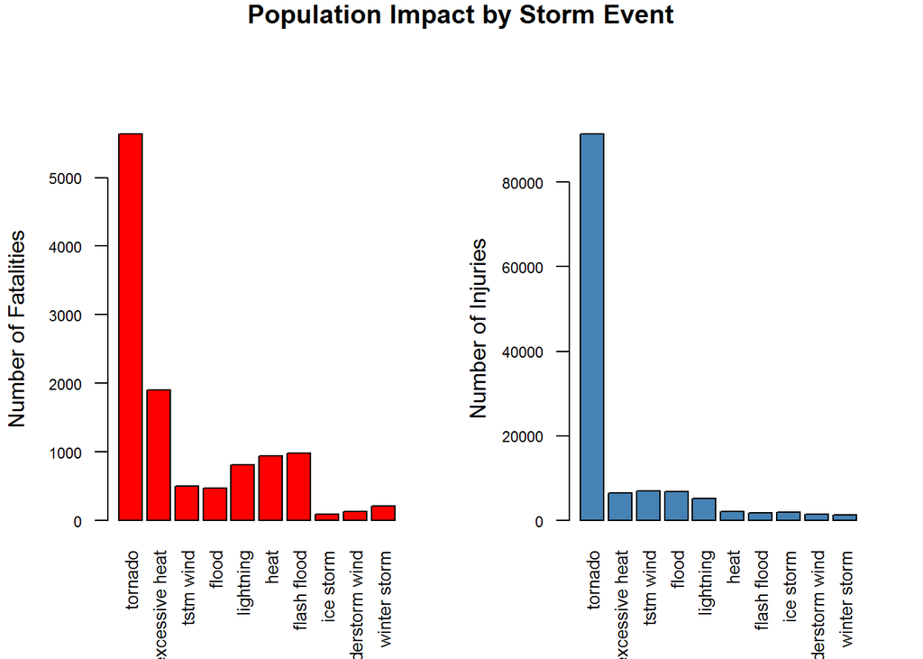

```r
par(mfrow=c(1,2), oma=c(0,0,1,0))

barplot(harm10$FATALITIES, names.arg=harm10$EVTYPE, las=2, cex.axis=0.7,
        cex.names=0.8,col="red",
        ylab="Number of Fatalities")
barplot(harm10$INJURIES, names.arg=harm10$EVTYPE, las=2, cex.axis=0.7,
        cex.names=0.8,col="steelblue",
        ylab="Number of Injuries")
title("Population Impact by Storm Event",outer=TRUE)
```

These plots show that tornadoes cause the highest impact to the number of both fatalities (at 5633) and injuries (at 91,346).

### Impact of Storm Events on the Economy

In order to look at the economical impact, we create the “econ” dataset from EVTYPE, PROPDMG, CROPDMG, and do a similar comparison that we did with the “harm” dataset.

```r
econ <- select(subStorm, EVTYPE, PROPDMG, CROPDMG)
econ <- econ[econ$PROPDMG>0 | econ$CROPDMG>0, ]

econ <- mutate(econ, total=PROPDMG + CROPDMG)
econ <- arrange(econ, desc(total))
econ10 <- econ[1:10, ]

econ10
```

```
##                EVTYPE   PROPDMG   CROPDMG     total
## 1             tornado 3212258.2 100018.52 3312276.7
## 2         flash flood 1420124.6 179200.46 1599325.1
## 3           tstm wind 1335995.6 109202.60 1445198.2
## 4                hail  688693.4 579596.28 1268289.7
## 5               flood  899938.5 168037.88 1067976.4
## 6   thunderstorm wind  876844.2  66791.45  943635.6
## 7           lightning  603351.8   3580.61  606932.4
## 8  thunderstorm winds  446293.2  18684.93  464978.1
## 9           high wind  324731.6  17283.21  342014.8
## 10       winter storm  132720.6   1978.99  134699.6
```

Plotting the events vs property damage and then crop damage, will show the impact on the economics.

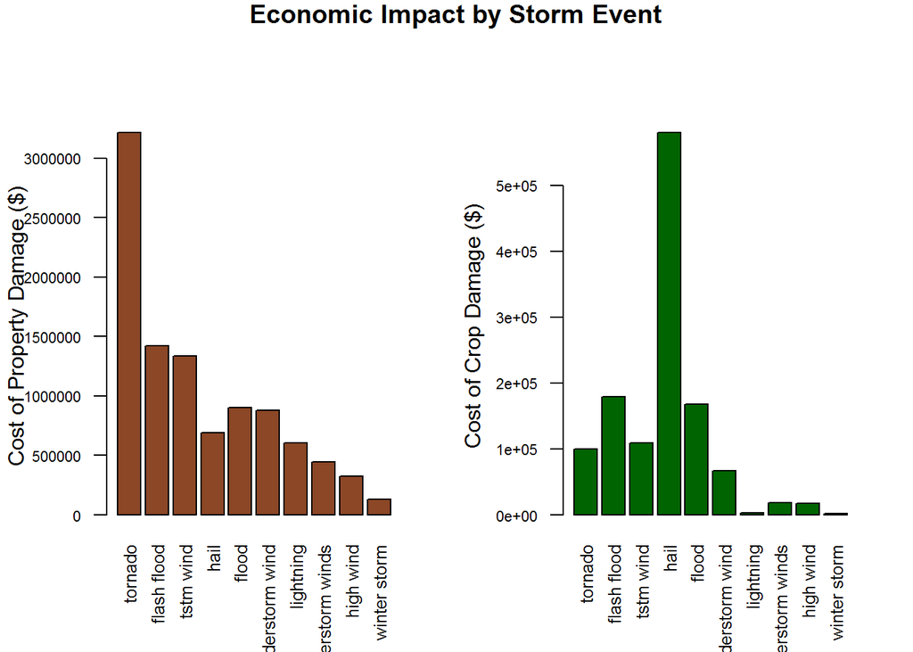

```r
par(mfrow=c(1,2), oma=c(0,0,1,0))

barplot(econ10$PROPDMG, names.arg=econ10$EVTYPE, las=2, cex.axis=0.7,
        cex.names=0.8,col="sienna4",
        ylab="Cost of Property Damage ($)")
barplot(econ10$CROPDMG, names.arg=econ10$EVTYPE, las=2, cex.axis=0.7,
        cex.names=0.8,col="darkgreen",
        ylab="Cost of Crop Damage ($)")
title("Economic Impact by Storm Event",outer=TRUE)
```

These plots show that tornadoes are the primary source of economic impact to property ($3,212,258), and hail is the cause of highest crop damage in terms of cost ($579,596).